# problem_8

Codes used to type and visualise the answers can be found [here](https://github.com/Satriawidy/ortvay_2026)

**Question**

The inhabitants of Flat Earth live on two square sides of a rectangular prism with side length $a$, thickness $h$, and homogeneous density $\rho$. The government of Flat Earth has had enough of the division. The Prime Minister issued an order: in the middle of both sides of Flat Earth, they should start drilling a small hole with a cross-section $A$ ($A \ll a^2$). Trusting that the two holes will eventually meet, they will succeed in uniting the inhabitants of both sides of Flat Earth. The energy required to transport the rock to the surface during excavation would be provided by the previously ordered nuclear power plant with capacity $P$. Money is no object. If everything goes well, how long will the excavation take? The excavated rock is currently near the hole, and its spreading is part of a later project.

(Data: $a = 10000$ km, $h = 2000$ km, $A = 5\text{~m}^2$, $\rho = 5500 \text{~kg/m}^3$, $P$ = 1000 MW)

**Answer**

To answer this question reasonably, we will assume that the Flat Earth has the technology to convert the nuclear output with constant efficiency $\eta$.

Based on those assumption, we can answer the question by posing another question: How much energy would it take to move all the rocks in the hole into their closest surface? Phrasing it into another question: What is the potential energy difference between the state of having all those rocks in its original place and putting them right on the surface?

To obtain the potential energy, we will need to first compute the gravitational potential field, especially close to the centre of the Flat Earth. To do that, we can opt to go with two different approach.

**Exact Model**

We can model the prism as layers of 2D square, which in turn can be modelled as piles of 1D line. The whole formulation gives \begin{align*} V(x, y, z) &= \int_{-h/2}^{h/2}dz'\int_{-a}^{a}dy'\int_{-a}^{a}dx'\frac{-G\rho}{\sqrt{(x'-x)^2 + (y'-y)^2 + (z'-z)^2}} \end{align*}

**Approximated Model**

We can use Gauss Law-like model. For gravity, the Gauss Law reads \begin{equation*} gA = 4\pi GM_A \end{equation*} We set the symmetric surface as a cylindrical tube which goes from $-h/2+z'$ to $h/2-z'$ and centered on the prism centre with cross section $A$. We then obtain \begin{equation*} g\left[2A\right] = 4\pi G\rho \left[2A\left(\frac{h}{2} - z'\right)\right] \implies g(z') = 4\pi G \rho \left[\frac{h}{2} - z'\right] \end{equation*} where $z$ is the distance from the surface. This leads to \begin{equation*} \Delta V_{\text{approx}}(z) = \int_0^z dz' ~(-g(z')) = 2\pi G\rho \left[\frac{h^2}{4} - \left(\frac{h}{2} - z\right)^2\right] \end{equation*}

**Semi-Exact Model**

We can connect both models by sequentially applying approximation to the exact models. First, we should move to the approximation frame, where $z$ is measured from the surface. We can, at the same time, reasonably assume that $\{x, y\} \rightarrow \{0, 0\}$, simplifying the potential to \begin{align*} V(x, y, z) \approx V(z) = \int_{0}^{h}dz'\int_{-a}^{a}dy'\int_{-a}^{a}dx'\frac{-G\rho}{\sqrt{x'^2 + y'^2 + (z'-z)^2}} \end{align*} Instead of integrating over a square with side $a$, we can instead consider a circle with radius $a$ \begin{align*} V(z) &\approx \int_{0}^{h}dz'\int_{0}^{a}dr ~2\pi r~\frac{-G\rho}{\sqrt{r^2 + (z'-z)^2}}\\ &\approx -\pi G\rho \int_{0}^{h}dz'\int_{0}^{a^2}\frac{dr^2}{\sqrt{r^2 + (z'-z)^2}}\\ &\approx -2\pi G\rho \int_{0}^{h}dz' \left[\sqrt{a^2 + (z'-z)^2} - \sqrt{(z'-z)^2}\right] \end{align*} The third modification is done by assuming $a^2\gg z^2$ (which is reasonable here given $a^2 = 25 h^2$), leading to $\sqrt{a^2 + (z'-z)^2}\approx a + \frac{(z'-z)^2}{2a}$. This leads to \begin{align*} V(z) \approx& 2\pi G\rho \int_{0}^{h}dz' \left[\sqrt{(z'-z)^2} - a - {(z'-z)^2}{2a}\right]\\ \approx& 2\pi G\rho \left[\int_{0}^{z}dz' (z-z') + \int_{z}^{h}dz'~(z'-z) - \int_{0}^{h}dz'~a - \int_0^{h} dz'~\frac{(z'-z)^2}{2a}\right]\\ \approx& 2\pi G\rho \left[\frac{z^2}{2} + \frac{1}{2}(h-z)^2 - ah - \frac{1}{6a}[(h-z)^3 + z^3]\right]\\ \approx& 2\pi G\rho \left[\frac{h^2}{4} + \left(\frac{h}{2} - z\right)^2 - ah - \frac{1}{6a}[(h-z)^3 + z^3]\right] \end{align*} This is similar, but not yet identical to the approximation. However, what we care about is the potential difference between $V(0)$ and $V(z)$. This is given by \begin{align*} \Delta V(z) &= V(0) - V(z)\\ &\approx 2\pi G\rho \left[\left[\frac{h^2}{4} - ah - \frac{h^3}{6a}\right] - \left[\frac{h^2}{4} + \left(\frac{h}{2} - z\right)^2 - ah - \frac{1}{6a}[(h-z)^3 + z^3]\right]\right]\\ &\approx 2\pi G\rho \left[\frac{h^2}{4} - \left(\frac{h}{2} - z\right)^2 + \frac{hz}{2a}[z - h]\right] \end{align*} This result shows that the approximated result is none other than the leading order of the full, exact result. We can increase the accuracy of our approximation by including higher and higher order in $(h/a)$.

**Numerical proof**

We would like to proceed with the rest of the calculation using the nice, analytically tractable semi-exact result. To strengthen our analytical proof, we will compute the exact potential difference numerically and compare it with the approximation. To evaluate the integral more efficiently, we turn it into scaleless form

\begin{align*} \frac{V(x/a,y/a,z/a)}{G\rho a^2} &= -\int_{-h/2a}^{h/2a}dz'\int_{-1}^{1}dy'\int_{-1}^{1}dx'\frac{1}{\sqrt{(x'-x)^2 + (y'-y)^2 + (z'-z)^2}} \end{align*}

and compare $[V(x/a,y/a,0) - V(x/a,y/a,z/a)]/(G\rho a^2)$ with \begin{equation*} \frac{\Delta V(z/a)}{G\rho a^2} = 2\pi\left[\left(\frac{h}{2a}\right)^2 - \left(\frac{h}{2a} - \frac{z}{a}\right)^2 + \frac{1}{2}\frac{h}{a}\frac{z}{a}\left(\frac{z}{a}-\frac{h}{a}\right)\right] \end{equation*}

```python
import numpy as np
from scipy.integrate import nquad
import matplotlib.pyplot as plt

# The scaleless potential
func = lambda z,y,x,a,b,c: -1 / ((x-c)**2 + (y-b)**2 + (z-a)**2 + 1e-12)**(0.5)


# Function to perform numerical integral
def integrate(hpa, zph, xpa, ypa):
    res = nquad(func, [[0, hpa], [-1, 1], [-1, 1]], [zph * hpa, xpa, ypa])
    app = 2 * np.pi * ((hpa/2)**2 - (hpa/2 - zph * hpa)**2
                       + hpa * zph * hpa * (zph * hpa - hpa) / 2)

    return res[0], res[1], app

# Function to repeat the test for different value of zphs
def test(hpa, xpa, ypa):
    zphs = np.arange(0, 1.05, 0.05)
    result = np.zeros_like(zphs)
    errors = np.zeros_like(zphs)
    approx = np.zeros_like(zphs)

    for i, zph in enumerate(zphs):
        a, b, c = integrate(hpa, zph, xpa, ypa)
        result[i] = a
        errors[i] = b
        approx[i] = c

    fig, axes = plt.subplots(nrows = 1, ncols = 2, figsize = (10, 4))
    ax = axes.flatten()

    ax[0].errorbar(zphs, result[0] - result,
                   errors + errors[0], label = 'exact')
    ax[0].plot(zphs, approx, label = 'approx')
    ax[0].legend()
    ax[1].errorbar(zphs[1:-1],
                   (result[0] - result[1:-1]) / approx[1:-1],
                   (errors[1:-1] + errors[0]) / approx[1:-1], fmt = 'o')
    ax[1].axhline(1)
    for a in ax:
        a.set_xlabel(r'$z/h$')
    fig.suptitle(f'h/a = {hpa}, x/a = {xpa}, y/a = {ypa}')
    plt.show()
```

To ensure that our test cover all region of interest, we will perform the test for $\{x/a, y/a\} = \{0, 0\}$ and $\{x, y\} = \{10^{-3}, 10^{-3}\}$. This should be more than enough as the latter represent even further region than what we need to inspect.

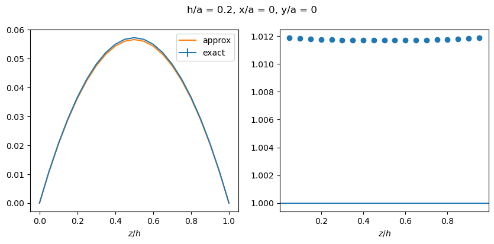

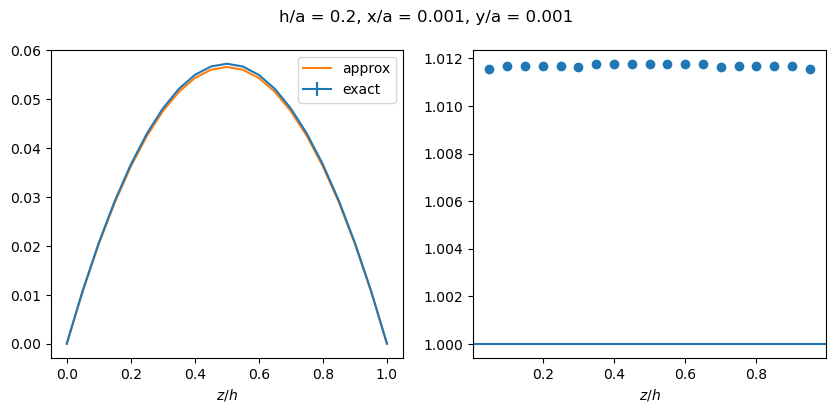

```python
test(0.2, 0, 0)
test(0.2, 1e-3, 1e-3)
```

We see that both choice of parameters show agreement up to $1\%$ between the exact and semi-exact result. This should be good enough, and even if we want to obtain further accuracy, we could reasonably use the factor $1.012$ to compensate their difference.

**Computing the required time**

Now we can proceed to compute the required energy. This is obtained by integrating the potential difference over the hole. We have seen that the potential difference is reasonably uniform over the $x,y$ direction inside the hole. It means that \begin{align*} \Delta \Phi &= \int_{0}^{h}dz~\rho A \Delta V(z)\\ &\approx 2\pi G\rho^2 A\int_0^{h}dz \left[\frac{h^2}{4} - \left(\frac{h}{2} - z\right)^2 + \frac{hz}{2a}[z - h]\right]\\ &\approx 2\pi G\rho^2 A \left[\frac{h^3}{4} - \frac{2}{3}\frac{h^3}{8} - \frac{h^4}{12a}\right]\\ &\approx \frac{\pi}{3} G\rho^2 A h^3\left[1 - \frac{h}{2a}\right] \end{align*}

with nuclear energy capacity $P$ and assumed efficiency $\eta$, we obtain the formula for the time \begin{align*} \Delta t = \frac{\Delta \Phi}{\eta P} \approx \frac{\frac{\pi}{3} G\rho^2 A h^3\left[1 - \frac{h}{2a}\right]}{\eta P} \end{align*}

Assuming $\eta = 1$, we can obtain the numerical results below, in the unit of days

```python
# The parameters, in SI unit

G = 6.67e-11
A = 5
a = 1e7
h = 2e6
P = 1e9
rho = 5500

# The required energy
end_res = G * (rho**2) * (h**3) * A * (1 - h / (2 * a)) * np.pi / 3

# The required time in seconds, further divided by 3600 seconds and 24 hours
# to obtain the result in the unit of days
print("Time in days:", end_res / (P * 3600 * 24))
```

```
Time in days: 880.3767996294147
```